# Анализ датасета Netflix 2025:User Behavior Dataset (210K+ Records)

**Цель:** Отработать навыки проектирования DWH на реальном датасете: спроектировать и исследовать реляционную структуру данных, автоматизировать ETL-процессы и реализовать комплекс бизнес-запросов.

**Датасет:** [Netflix 2025: User Behavior Dataset](https://kaggle.com) — 210 000+ записей и 6 связанных таблиц.

**Стек:** · PostgreSQL · SQLAlchemy · DBeaver · Python · Jupyter Notebook · Pandas · Matplotlib · Seaborn

## Структура анализа

1. Развёртывание DWH и изучение ER-схемы в DBeaver
2. Анализ географии притока аудитории
3. Месячная динамика активности пользователей (MAU)
4. Конверсия поиска по устройствам
5. Скользящее среднее 7 дней
6. ТОП-10 жанров
7. Когортный анализ удержания пользователей
8. Темп роста МоМ
9. ТОП-3 фильма внутри каждого жанра
10. Финансовый профиль тарифов
11. Влияние качества трансляции на оценки
12. Анализ оттока пользователей

```python
import os
print(os.getcwd())
```

```
/Users/elizaveta/netflix_analytics/netflix_analytics
```

```python
import pandas as pd
import matplotlib.pyplot as plt
import seaborn as sns
from sqlalchemy import create_engine

sns.set_theme(style="whitegrid")
engine = create_engine('postgresql://postgres:1234@localhost:5432/netflix_dwh')
tables = ["users", "movies", "watch_history", "reviews", "search_logs", "recommendation_logs"]
dfs = {name: pd.read_csv(f"{name}.csv") for name in tables}
dfs["users"] = dfs["users"].drop_duplicates()
dfs["reviews"]["review_text"] = dfs["reviews"]["review_text"].fillna("No text")
date_cols = {
    "users": "subscription_start_date",
    "watch_history": "watch_date",
    "search_logs": "search_date",
    "recommendation_logs": "recommendation_date"
}
for t_name, col in date_cols.items():
    if col in dfs[t_name].columns:
        dfs[t_name][col] = pd.to_datetime(dfs[t_name][col], errors='coerce')
for name, df in dfs.items():
    df.to_sql(name, engine, if_exists="replace", index=False)
```

# 1. Развёртывание DWH и изучение ER-схемы в DBeaver

Изучим, по каким первичным ключам соединены таблицы и какие столбцы входят в каждую из них.

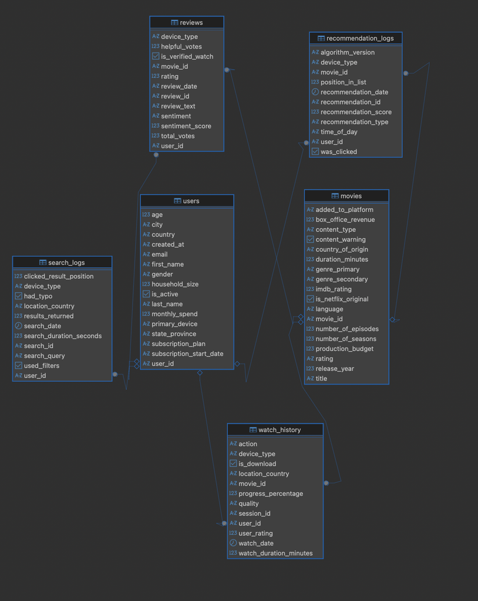

```python
from IPython.display import Image, display
display(Image(filename='ER таблица.png', width=800))
```

# 2. Анализ географии притока аудитории

Проанализируем географию пользователей, остортируем по убыванию пользователей и составим рейтинг по штатам/провинциям.

```python
geography = pd.read_sql("""
    SELECT
    country,
    state_province,
    COUNT(user_id) AS total_new_users
FROM users
GROUP BY country, state_province
ORDER BY total_new_users DESC;
""", engine)
geography
```

|  | country | state_province | total_new_users |
| --- | --- | --- | --- |
| 0 | USA | North Carolina | 397 |
| 1 | USA | Tennessee | 380 |
| 2 | USA | Texas | 369 |
| 3 | USA | Indiana | 361 |
| 4 | USA | Michigan | 353 |
| 5 | USA | Arizona | 350 |
| 6 | USA | Virginia | 349 |
| 7 | USA | Wisconsin | 349 |
| 8 | USA | California | 348 |
| 9 | USA | Maryland | 346 |
| 10 | USA | Illinois | 343 |
| 11 | USA | Georgia | 342 |
| 12 | USA | Pennsylvania | 342 |
| 13 | USA | Ohio | 341 |
| 14 | USA | New Jersey | 341 |
| 15 | USA | New York | 340 |
| 16 | USA | Florida | 340 |
| 17 | USA | Missouri | 339 |
| 18 | USA | Massachusetts | 339 |
| 19 | Canada | Nova Scotia | 336 |
| 20 | USA | Washington | 324 |
| 21 | Canada | Ontario | 312 |
| 22 | Canada | Quebec | 310 |
| 23 | Canada | Prince Edward Island | 306 |
| 24 | Canada | Alberta | 300 |
| 25 | Canada | British Columbia | 298 |
| 26 | Canada | Newfoundland and Labrador | 298 |
| 27 | Canada | Manitoba | 289 |
| 28 | Canada | New Brunswick | 283 |
| 29 | Canada | Saskatchewan | 275 |

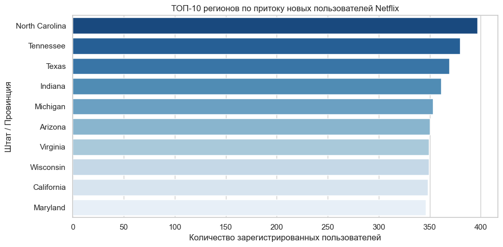

```python
plt.figure(figsize=(10,5))
sns.barplot(
    data=geography.head(10),
    x='total_new_users',
    y='state_province',
    palette='Blues_r',
    hue='state_province',
    legend=False
)
plt.title('ТОП-10 регионов по притоку новых пользователей Netflix')
plt.xlabel('Количество зарегистрированных пользователей')
plt.ylabel('Штат / Провинция')
plt.tight_layout()
plt.show()
```

**Вывод:** Новая аудитория живет в США (подавляющее большинство) и Канаде. Новые пользователи преимущественно живут в Северной Каролине, Теннесси и Техасе, а многомиллионный штат Калифорния занимает лишь 9 место. Значит мегаполисы достигли точки плато, следовательно основным притоком аудитории являются регионы. Рекомендация: перенаправить часть маркетингового бюджета в другие штаты, со средней плотностью населения.

# 3. Месячная динамика активности пользователей (MAU)

Найдем, в какой период падает активность просмотра контента

```python
mau = pd.read_sql("""
    SELECT COUNT(DISTINCT user_id) AS active_users,
		SUM(watch_duration_minutes) AS total_minutes,
		TO_CHAR(watch_date::TIMESTAMP, 'YYYY-MM') AS period,
		ROUND((SUM(watch_duration_minutes)::NUMERIC/ COUNT(DISTINCT user_id)), 2) AS average_sum
FROM watch_history
GROUP BY period
ORDER BY period ASC;
""", engine)
mau
```

|  | active_users | total_minutes | period | average_sum |
| --- | --- | --- | --- | --- |
| 0 | 3372 | 256900.9 | 2024-01 | 76.19 |
| 1 | 3384 | 242275.2 | 2024-02 | 71.59 |
| 2 | 3380 | 250797.5 | 2024-03 | 74.20 |
| 3 | 3387 | 244527.7 | 2024-04 | 72.20 |
| 4 | 3551 | 270953.5 | 2024-05 | 76.30 |
| 5 | 3445 | 261397.6 | 2024-06 | 75.88 |
| 6 | 3398 | 261720.3 | 2024-07 | 77.02 |
| 7 | 3551 | 269303.1 | 2024-08 | 75.84 |
| 8 | 3323 | 251892.0 | 2024-09 | 75.80 |
| 9 | 3434 | 255226.5 | 2024-10 | 74.32 |
| 10 | 3331 | 236574.4 | 2024-11 | 71.02 |
| 11 | 3539 | 268562.2 | 2024-12 | 75.89 |
| 12 | 3424 | 255829.7 | 2025-01 | 74.72 |
| 13 | 3118 | 223745.4 | 2025-02 | 71.76 |
| 14 | 3403 | 257051.5 | 2025-03 | 75.54 |
| 15 | 3373 | 251757.0 | 2025-04 | 74.64 |
| 16 | 3438 | 260526.5 | 2025-05 | 75.78 |
| 17 | 3341 | 241823.2 | 2025-06 | 72.38 |
| 18 | 3481 | 267581.7 | 2025-07 | 76.87 |
| 19 | 3341 | 251541.4 | 2025-08 | 75.29 |
| 20 | 3289 | 245382.5 | 2025-09 | 74.61 |
| 21 | 3436 | 249492.8 | 2025-10 | 72.61 |
| 22 | 3363 | 248512.4 | 2025-11 | 73.90 |
| 23 | 3539 | 264193.4 | 2025-12 | 74.65 |

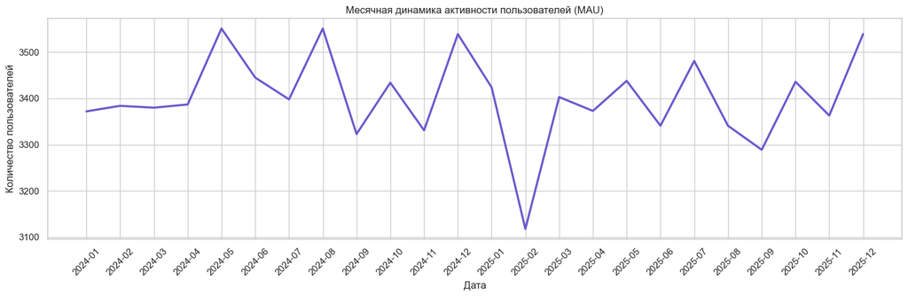

```python
plt.figure(figsize=(15,5))
sns.lineplot(
    data=mau,
    x='period',
    y='active_users',
    color='#6A5ACD',
    linewidth=2.5
)
plt.title('Месячная динамика активности пользователей (MAU)')
plt.xlabel('Дата')
plt.ylabel('Количество пользователей')
plt.xticks(rotation=45)
plt.tight_layout()
plt.show()
```

# 4. Конверсия поиска по устройствам

Выясним, с каких устройств пользователи чаще всего ищут фильмы и насколько успешно эти поиски заканчиваются реальным просмотром.

```python
device = pd.read_sql("""
    SELECT device_type,
    	COUNT(search_id) AS total_searches,
    	COUNT(clicked_result_position) AS clicked_searches,
    	ROUND((COUNT(clicked_result_position)::NUMERIC / COUNT(search_id) * 100), 2) AS conversion
FROM search_logs
GROUP BY device_type
ORDER BY conversion DESC;""", engine)
device
```

|  | device_type | total_searches | clicked_searches | conversion |
| --- | --- | --- | --- | --- |
| 0 | Laptop | 6585 | 3263 | 49.55 |
| 1 | Mobile | 6563 | 3230 | 49.22 |
| 2 | Tablet | 6783 | 3286 | 48.44 |
| 3 | Smart TV | 6569 | 3172 | 48.29 |

**Вывод:** Эффективность поиска практически одинакова на всех типах устройств. Конверсия из поискового запроса в клик стабильно держится в районе 48–49%. Лидируют ноутбуки, а Smart TV незначительно отстает, это говорит о том, что поисковый интерфейс платформы одинаково удобен для пользователей на любых устройствах. Поскольку интерфейс работает стабильно, то стоит сфокусироваться на улучшении алгоритмов предложенных рекомендаций.

# 5. Скользящее среднее 7 дней

Найдем сглаженный недельный тренд просмотров, чтобы очистить данные от хаотичных скачков активности в выходные дни.

```python
rolling_7_days = pd.read_sql("""
    SELECT watch_date,
            SUM(watch_duration_minutes) AS day_value,
            ROUND(AVG(SUM(watch_duration_minutes)) OVER(
            ORDER BY watch_date ROWS BETWEEN 6 PRECEDING AND CURRENT ROW)::numeric, 1) AS rolling_7_day_avg
    FROM watch_history
    GROUP BY watch_date
    ORDER BY watch_date ASC;""", engine)
rolling_7_days
```

|  | watch_date | day_value | rolling_7_day_avg |
| --- | --- | --- | --- |
| 0 | 2024-01-01 | 7341.2 | 7341.2 |
| 1 | 2024-01-02 | 9906.9 | 8624.1 |
| 2 | 2024-01-03 | 7228.2 | 8158.8 |
| 3 | 2024-01-04 | 7352.4 | 7957.2 |
| 4 | 2024-01-05 | 7433.8 | 7852.5 |
| ... | ... | ... | ... |
| 726 | 2025-12-27 | 8739.9 | 8935.2 |
| 727 | 2025-12-28 | 6679.1 | 8805.3 |
| 728 | 2025-12-29 | 9811.5 | 9075.5 |
| 729 | 2025-12-30 | 8077.0 | 9018.6 |
| 730 | 2025-12-31 | 7600.9 | 8564.4 |

731 rows × 3 columns

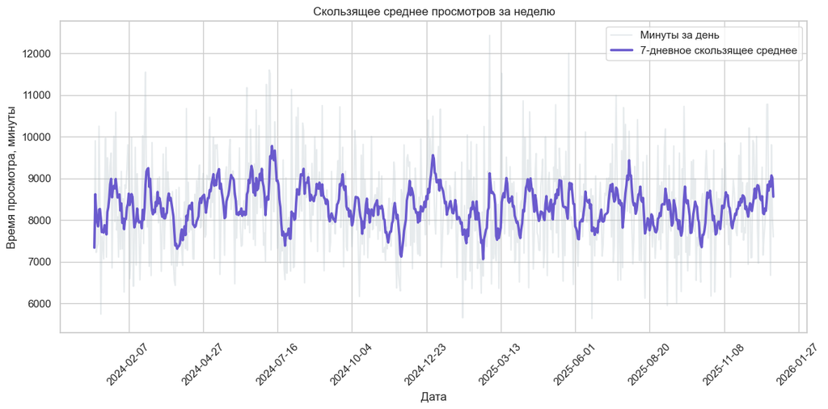

```python
import matplotlib.ticker as ticker
plt.figure(figsize=(12, 6))
sns.lineplot(
    data=rolling_7_days,
    x='watch_date',
    y='day_value',
    label='Минуты за день',
    color='#B0BEC5',
    alpha=0.3
)
sns.lineplot(
    data=rolling_7_days,
    x='watch_date',
    y='rolling_7_day_avg',
    label='7-дневное скользящее среднее',
    color='#6A5ACD',
    linewidth=2.5
)
plt.title('Скользящее среднее просмотров за неделю')
plt.xlabel('Дата')
plt.ylabel('Время просмотра, минуты')
plt.gca().xaxis.set_major_locator(ticker.MaxNLocator(12))
plt.xticks(rotation=45)
plt.legend()
plt.tight_layout()
plt.show()
```

**Вывод:** На графике видны пики роста — моменты, когда Netflix выпускает премьеры, а люди возвращаются к экранам.

# 6. ТОП-10 жанров

Найдем, какие жанры наиболее популярны

```python
genre=pd.read_sql("""
    SELECT m.genre_primary,
		COUNT(DISTINCT wh.user_id) AS unique_watch,
		SUM(wh.watch_duration_minutes) AS total_minutes
FROM watch_history wh
INNER JOIN movies m ON wh.movie_id = m.movie_id
GROUP BY m.genre_primary
ORDER BY total_minutes DESC
LIMIT 10;""", engine)
genre
```

|  | genre_primary | unique_watch | total_minutes |
| --- | --- | --- | --- |
| 0 | Adventure | 4914 | 443280.8 |
| 1 | War | 4349 | 375281.4 |
| 2 | Animation | 4461 | 373216.8 |
| 3 | Sci-Fi | 4286 | 364505.4 |
| 4 | Action | 4353 | 360255.7 |
| 5 | Comedy | 4418 | 357961.7 |
| 6 | Romance | 3988 | 344227.4 |
| 7 | History | 4071 | 337278.4 |
| 8 | Western | 4208 | 329155.8 |
| 9 | Biography | 4016 | 323790.5 |

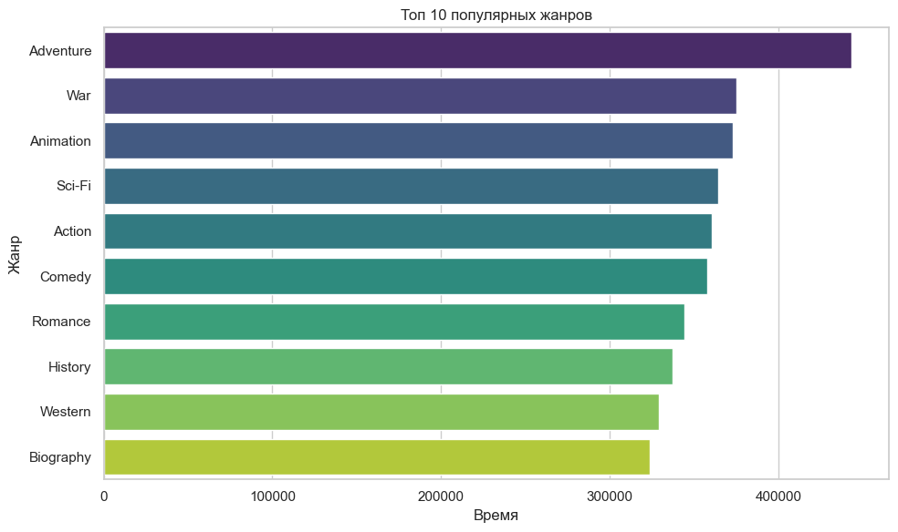

```python
plt.figure(figsize=(10,6))
sns.barplot(
    data=genre,
    x='total_minutes',
    y='genre_primary',
    palette='viridis',
    hue='genre_primary',
    legend=False
)
plt.title('Топ 10 популярных жанров')
plt.xlabel('Время')
plt.ylabel('Жанр')
plt.tight_layout()
plt.show()
```

**Вывод:** Лидером по времени просмотра стали Приключения, это показывает, что аудитория платформы предпочитает динамичный и зрелищный контент. Тогда, при планировании бюджетов на производство контента стоит делать фокус именно на приключенческие экшены.

# 7. Когортный анализ удержания пользователей

Посмотрим, как долго пользователь активен после месяца регистрации на платформе.

```python
cohort = pd.read_sql("""
WITH user_cohorts AS (
	SELECT DISTINCT user_id,
            subscription_start_date::date AS cohort_start
    FROM users
),
user_activities AS (
    SELECT DISTINCT user_id,
           watch_date::date AS activity_date
    FROM watch_history
)
SELECT
    TO_CHAR(uc.cohort_start, 'YYYY-MM') AS period,
    (EXTRACT(YEAR FROM AGE(ua.activity_date, uc.cohort_start)) * 12 +
     EXTRACT(MONTH FROM AGE(ua.activity_date, uc.cohort_start))) AS lifetime_month,
     COUNT(DISTINCT uc.user_id) AS active_users
FROM user_cohorts uc
JOIN user_activities ua ON uc.user_id = ua.user_id
WHERE ua.activity_date >= uc.cohort_start
GROUP BY TO_CHAR(uc.cohort_start, 'YYYY-MM'), lifetime_month
ORDER BY period ASC, lifetime_month ASC;
""", engine)
cohort
```

|  | period | lifetime_month | active_users |
| --- | --- | --- | --- |
| 0 | 2022-08 | 16.0 | 56 |
| 1 | 2022-08 | 17.0 | 91 |
| 2 | 2022-08 | 18.0 | 99 |
| 3 | 2022-08 | 19.0 | 96 |
| 4 | 2022-08 | 20.0 | 93 |
| ... | ... | ... | ... |
| 709 | 2025-07 | 5.0 | 44 |
| 710 | 2025-08 | 1.0 | 5 |
| 711 | 2025-08 | 2.0 | 4 |
| 712 | 2025-08 | 3.0 | 1 |
| 713 | 2025-08 | 4.0 | 1 |

714 rows × 3 columns

**Вывод:** Анализ данных показывает, что удержание пользователей стабильно. Количество активных зрителей внутри групп не падает до нуля со временем, что говорит хорошем удержании аудитории.

# 8. Темп роста МоМ

Посчитаем процентный прирост или падение активной аудитории (MAU) каждого месяца по отношению к предыдущему.

```python
mau = pd.read_sql("""
WITH monthly_mau AS (
  SELECT
    COUNT(DISTINCT user_id) AS active_users,
    TO_CHAR(watch_date::timestamp, 'YYYY-MM') AS year_month
  FROM watch_history
  GROUP BY TO_CHAR(watch_date::timestamp, 'YYYY-MM')
)
SELECT
  year_month,
  active_users,
  ROUND((active_users - LAG(active_users, 1) OVER (ORDER BY year_month))::numeric
    / LAG(active_users, 1) OVER (ORDER BY year_month) * 100, 2) AS growth_pct
FROM monthly_mau;""", engine)
mau
```

|  | year_month | active_users | growth_pct |
| --- | --- | --- | --- |
| 0 | 2024-01 | 3372 | NaN |
| 1 | 2024-02 | 3384 | 0.36 |
| 2 | 2024-03 | 3380 | -0.12 |
| 3 | 2024-04 | 3387 | 0.21 |
| 4 | 2024-05 | 3551 | 4.84 |
| 5 | 2024-06 | 3445 | -2.99 |
| 6 | 2024-07 | 3398 | -1.36 |
| 7 | 2024-08 | 3551 | 4.50 |
| 8 | 2024-09 | 3323 | -6.42 |
| 9 | 2024-10 | 3434 | 3.34 |
| 10 | 2024-11 | 3331 | -3.00 |
| 11 | 2024-12 | 3539 | 6.24 |
| 12 | 2025-01 | 3424 | -3.25 |
| 13 | 2025-02 | 3118 | -8.94 |
| 14 | 2025-03 | 3403 | 9.14 |
| 15 | 2025-04 | 3373 | -0.88 |
| 16 | 2025-05 | 3438 | 1.93 |
| 17 | 2025-06 | 3341 | -2.82 |
| 18 | 2025-07 | 3481 | 4.19 |
| 19 | 2025-08 | 3341 | -4.02 |
| 20 | 2025-09 | 3289 | -1.56 |
| 21 | 2025-10 | 3436 | 4.47 |
| 22 | 2025-11 | 3363 | -2.12 |
| 23 | 2025-12 | 3539 | 5.23 |

# 9. ТОП-3 фильма внутри каждого жанра

Найдем тройку лидеров фильмов в внутри каждого жанра, чтобы сформировать список рекомендаций для новых пользователей

```python
rating = pd.read_sql("""
WITH movie_rating AS (
	SELECT genre_primary,
	    	title,
			ROUND(AVG(r.rating)::NUMERIC,1) AS average_rating,
			DENSE_RANK() OVER(PARTITION BY genre_primary ORDER BY AVG(r.rating) DESC) AS top_rating
	FROM movies m
	JOIN reviews r ON r.movie_id = m.movie_id
	GROUP BY genre_primary, title
)
SELECT genre_primary,
		title,
		average_rating,
		top_rating
FROM movie_rating
WHERE top_rating <= 3
ORDER BY genre_primary ASC, top_rating ASC;""", engine)
rating
```

|  | genre_primary | title | average_rating | top_rating |
| --- | --- | --- | --- | --- |
| 0 | Action | Legend Queen | 4.1 | 1 |
| 1 | Action | Little Warrior | 4.1 | 2 |
| 2 | Action | Dark Love | 4.1 | 3 |
| 3 | Adventure | Story Fire | 4.2 | 1 |
| 4 | Adventure | Family Kingdom | 4.2 | 2 |
| ... | ... | ... | ... | ... |
| 69 | Western | House House | 4.0 | 2 |
| 70 | Western | Hero Mystery | 4.0 | 2 |
| 71 | Western | Journey Mystery | 4.0 | 2 |
| 72 | Western | Empire War | 4.0 | 2 |
| 73 | Western | King Warrior | 4.0 | 3 |

74 rows × 4 columns

# 10. Финансовый профиль тарифных планов

Посчитаем количество подписчиков и средний чек для каждого тарифного плана и оценим вклад каждого сегмента в общую выручку.

```python
finance = pd.read_sql("""
SELECT COUNT(DISTINCT user_id),
		subscription_plan,
		ROUND(AVG(monthly_spend)::NUMERIC, 1) AS average_spend
FROM users
GROUP BY subscription_plan
ORDER BY average_spend DESC;""", engine)
finance
```

|  | count | subscription_plan | average_spend |
| --- | --- | --- | --- |
| 0 | 3522 | Standard | 24.3 |
| 1 | 3507 | Premium | 21.7 |
| 2 | 1966 | Basic | 20.6 |
| 3 | 1005 | Premium+ | 20.5 |

**Вывод:** Основную массу подписчиков генерируют тарифы Standard и Premium. Поскольку данные были созданы искусственно, парадоксально, что тариф Standard является самым высоким на платформе, опережая Premium.

# 11. Влияние качества трансляции на оценки

Посмотрим, как качество трансляции влияет на средние оценки.

```python
film_quality = pd.read_sql("""
SELECT quality,
		COUNT(review_id) AS total_review,
		ROUND(AVG(r.rating)::NUMERIC, 2) AS average_rating
FROM reviews r
JOIN watch_history wh ON wh.user_id = r.user_id AND wh.movie_id = r.movie_id
GROUP BY quality
ORDER BY average_rating DESC;""", engine)
film_quality
```

|  | quality | total_review | average_rating |
| --- | --- | --- | --- |
| 0 | Ultra HD | 8 | 4.63 |
| 1 | SD | 19 | 3.74 |
| 2 | HD | 66 | 3.53 |
| 3 | 4K | 40 | 3.40 |

**Вывод:** Самую высокую среднюю оценку получили просмотры в Ultra HD, при этом формат 4K показал худший результат на платформе. Это говорит о том, что при переходе на тяжелый 4K-контент пользователи сталкиваются с техническими проблемами, из-за чего занижают оценки фильмам.

# 12. Анализ оттока пользователей

Найдем пользователей, которые не посмотрели контента за декабрь 2025 года, чтобы локализовать зоны риска потери выручки.

```python
subplan = pd.read_sql("""
SELECT COUNT(DISTINCT u.user_id) AS user_count,
		u.country,
		u.subscription_plan
FROM users u
LEFT JOIN watch_history wh ON wh.user_id = u.user_id
								AND EXTRACT(MONTH FROM wh.watch_date::TIMESTAMP) = 12
								AND EXTRACT(YEAR FROM wh.watch_date::TIMESTAMP) = 2025
WHERE wh.user_id IS NULL
GROUP BY u.subscription_plan, u.country
ORDER BY user_count DESC;""", engine)
subplan
```

|  | user_count | country | subscription_plan |
| --- | --- | --- | --- |
| 0 | 1609 | USA | Premium |
| 1 | 1572 | USA | Standard |
| 2 | 849 | USA | Basic |
| 3 | 707 | Canada | Premium |
| 4 | 672 | Canada | Standard |
| 5 | 487 | USA | Premium+ |
| 6 | 393 | Canada | Basic |
| 7 | 172 | Canada | Premium+ |

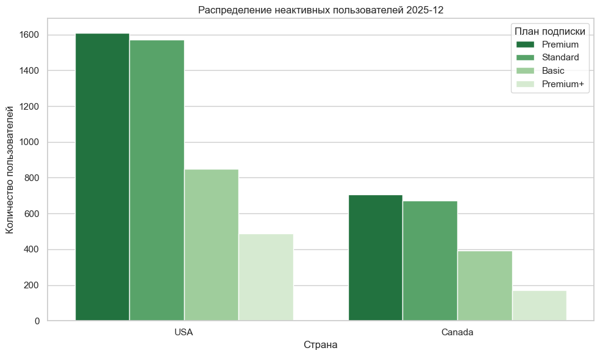

```python
plt.figure(figsize=(10,6))
sns.barplot(
    data=subplan,
    x='country',
    y='user_count',
    hue='subscription_plan',
    palette='Greens_r'
)
plt.title('Распределение неактивных пользователей 2025-12')
plt.xlabel('Страна')
plt.ylabel('Количество пользователей')
plt.legend(title='План подписки')
plt.tight_layout()
plt.show()
```

**Вывод:** Основная масса "неактивных" платящих пользователей сосредоточена на самых дорогих тарифах — Premium и Standard, причём в США этот показатель превышает 1500 человек на каждый тариф. Чтобы уменьшить потенциальный отток, стоит предложить им новинки фильмов и сериалов, отправить персональные подборки и напомнить о преимуществах их подписки.